# Risk Factor Analysis

## Outcome Variable

**Outcome Variable:** sstunted

## Predictor Variables

**Intervention Variable:** birthwt

**Adjustment Set:**

unadjusted

## Stratifying Variables

The analysis was stratified on these variable(s):

- agecat
- studyid
- country

## Data Summary

| agecat | studyid | country | birthwt | sstunted | n_cell | n |
| --- | --- | --- | --- | --- | --- | --- |
| Birth | CMC-V-BCS-2002 | INDIA | Normal or high birthweight | 0 | 78 | 92 |
| Birth | CMC-V-BCS-2002 | INDIA | Normal or high birthweight | 1 | 3 | 92 |
| Birth | CMC-V-BCS-2002 | INDIA | Low birthweight | 0 | 10 | 92 |
| Birth | CMC-V-BCS-2002 | INDIA | Low birthweight | 1 | 1 | 92 |
| Birth | CMIN | BANGLADESH | Normal or high birthweight | 0 | 14 | 26 |
| Birth | CMIN | BANGLADESH | Normal or high birthweight | 1 | 0 | 26 |
| Birth | CMIN | BANGLADESH | Low birthweight | 0 | 6 | 26 |
| Birth | CMIN | BANGLADESH | Low birthweight | 1 | 6 | 26 |
| Birth | COHORTS | GUATEMALA | Normal or high birthweight | 0 | 713 | 784 |
| Birth | COHORTS | GUATEMALA | Normal or high birthweight | 1 | 4 | 784 |
| Birth | COHORTS | GUATEMALA | Low birthweight | 0 | 61 | 784 |
| Birth | COHORTS | GUATEMALA | Low birthweight | 1 | 6 | 784 |
| Birth | COHORTS | INDIA | Normal or high birthweight | 0 | 5242 | 6638 |
| Birth | COHORTS | INDIA | Normal or high birthweight | 1 | 26 | 6638 |
| Birth | COHORTS | INDIA | Low birthweight | 0 | 1190 | 6638 |
| Birth | COHORTS | INDIA | Low birthweight | 1 | 180 | 6638 |
| Birth | COHORTS | PHILIPPINES | Normal or high birthweight | 0 | 2704 | 3004 |
| Birth | COHORTS | PHILIPPINES | Normal or high birthweight | 1 | 5 | 3004 |
| Birth | COHORTS | PHILIPPINES | Low birthweight | 0 | 255 | 3004 |
| Birth | COHORTS | PHILIPPINES | Low birthweight | 1 | 40 | 3004 |
| Birth | CONTENT | PERU | Normal or high birthweight | 0 | 2 | 2 |
| Birth | CONTENT | PERU | Normal or high birthweight | 1 | 0 | 2 |
| Birth | CONTENT | PERU | Low birthweight | 0 | 0 | 2 |
| Birth | CONTENT | PERU | Low birthweight | 1 | 0 | 2 |
| Birth | EE | PAKISTAN | Normal or high birthweight | 0 | 148 | 240 |
| Birth | EE | PAKISTAN | Normal or high birthweight | 1 | 12 | 240 |
| Birth | EE | PAKISTAN | Low birthweight | 0 | 44 | 240 |
| Birth | EE | PAKISTAN | Low birthweight | 1 | 36 | 240 |
| Birth | GMS-Nepal | NEPAL | Normal or high birthweight | 0 | 475 | 696 |
| Birth | GMS-Nepal | NEPAL | Normal or high birthweight | 1 | 1 | 696 |

[output cut: 282 more lines]

The following strata were considered:

- agecat: 24 months, studyid: CMC-V-BCS-2002, country: INDIA
- agecat: 24 months, studyid: CMIN, country: BANGLADESH
- agecat: 24 months, studyid: COHORTS, country: GUATEMALA
- agecat: 24 months, studyid: COHORTS, country: INDIA
- agecat: 24 months, studyid: COHORTS, country: PHILIPPINES
- agecat: 24 months, studyid: CONTENT, country: PERU
- agecat: 24 months, studyid: EE, country: PAKISTAN
- agecat: 24 months, studyid: GMS-Nepal, country: NEPAL
- agecat: 24 months, studyid: IRC, country: INDIA
- agecat: 24 months, studyid: JiVitA-3, country: BANGLADESH
- agecat: 24 months, studyid: JiVitA-4, country: BANGLADESH
- agecat: 24 months, studyid: Keneba, country: GAMBIA
- agecat: 24 months, studyid: MAL-ED, country: BANGLADESH
- agecat: 24 months, studyid: MAL-ED, country: BRAZIL
- agecat: 24 months, studyid: MAL-ED, country: INDIA
- agecat: 24 months, studyid: MAL-ED, country: NEPAL
- agecat: 24 months, studyid: MAL-ED, country: PERU
- agecat: 24 months, studyid: MAL-ED, country: SOUTH AFRICA
- agecat: 24 months, studyid: MAL-ED, country: TANZANIA, UNITED REPUBLIC OF
- agecat: 24 months, studyid: NIH-Birth, country: BANGLADESH
- agecat: 24 months, studyid: NIH-Crypto, country: BANGLADESH
- agecat: 24 months, studyid: PROBIT, country: BELARUS
- agecat: 24 months, studyid: PROVIDE, country: BANGLADESH
- agecat: 24 months, studyid: TanzaniaChild2, country: TANZANIA, UNITED REPUBLIC OF
- agecat: 24 months, studyid: ZVITAMBO, country: ZIMBABWE
- agecat: 6 months, studyid: CMC-V-BCS-2002, country: INDIA
- agecat: 6 months, studyid: CMIN, country: BANGLADESH
- agecat: 6 months, studyid: COHORTS, country: GUATEMALA
- agecat: 6 months, studyid: COHORTS, country: INDIA
- agecat: 6 months, studyid: COHORTS, country: PHILIPPINES
- agecat: 6 months, studyid: CONTENT, country: PERU
- agecat: 6 months, studyid: EE, country: PAKISTAN
- agecat: 6 months, studyid: GMS-Nepal, country: NEPAL
- agecat: 6 months, studyid: IRC, country: INDIA
- agecat: 6 months, studyid: JiVitA-3, country: BANGLADESH
- agecat: 6 months, studyid: JiVitA-4, country: BANGLADESH
- agecat: 6 months, studyid: Keneba, country: GAMBIA
- agecat: 6 months, studyid: MAL-ED, country: BANGLADESH
- agecat: 6 months, studyid: MAL-ED, country: BRAZIL
- agecat: 6 months, studyid: MAL-ED, country: INDIA
- agecat: 6 months, studyid: MAL-ED, country: NEPAL
- agecat: 6 months, studyid: MAL-ED, country: PERU
- agecat: 6 months, studyid: MAL-ED, country: SOUTH AFRICA
- agecat: 6 months, studyid: MAL-ED, country: TANZANIA, UNITED REPUBLIC OF
- agecat: 6 months, studyid: NIH-Birth, country: BANGLADESH
- agecat: 6 months, studyid: NIH-Crypto, country: BANGLADESH
- agecat: 6 months, studyid: PROBIT, country: BELARUS
- agecat: 6 months, studyid: PROVIDE, country: BANGLADESH
- agecat: 6 months, studyid: ResPak, country: PAKISTAN
- agecat: 6 months, studyid: SAS-CompFeed, country: INDIA
- agecat: 6 months, studyid: TanzaniaChild2, country: TANZANIA, UNITED REPUBLIC OF
- agecat: 6 months, studyid: ZVITAMBO, country: ZIMBABWE
- agecat: Birth, studyid: CMC-V-BCS-2002, country: INDIA
- agecat: Birth, studyid: CMIN, country: BANGLADESH
- agecat: Birth, studyid: COHORTS, country: GUATEMALA
- agecat: Birth, studyid: COHORTS, country: INDIA
- agecat: Birth, studyid: COHORTS, country: PHILIPPINES
- agecat: Birth, studyid: CONTENT, country: PERU
- agecat: Birth, studyid: EE, country: PAKISTAN
- agecat: Birth, studyid: GMS-Nepal, country: NEPAL
- agecat: Birth, studyid: IRC, country: INDIA
- agecat: Birth, studyid: JiVitA-3, country: BANGLADESH
- agecat: Birth, studyid: JiVitA-4, country: BANGLADESH
- agecat: Birth, studyid: Keneba, country: GAMBIA
- agecat: Birth, studyid: MAL-ED, country: BANGLADESH
- agecat: Birth, studyid: MAL-ED, country: BRAZIL
- agecat: Birth, studyid: MAL-ED, country: INDIA
- agecat: Birth, studyid: MAL-ED, country: NEPAL
- agecat: Birth, studyid: MAL-ED, country: PERU
- agecat: Birth, studyid: MAL-ED, country: SOUTH AFRICA
- agecat: Birth, studyid: MAL-ED, country: TANZANIA, UNITED REPUBLIC OF
- agecat: Birth, studyid: NIH-Birth, country: BANGLADESH
- agecat: Birth, studyid: NIH-Crypto, country: BANGLADESH
- agecat: Birth, studyid: PROBIT, country: BELARUS
- agecat: Birth, studyid: PROVIDE, country: BANGLADESH
- agecat: Birth, studyid: ResPak, country: PAKISTAN
- agecat: Birth, studyid: SAS-CompFeed, country: INDIA
- agecat: Birth, studyid: ZVITAMBO, country: ZIMBABWE

### Dropped Strata

Some strata were dropped due to rare outcomes:

- agecat: Birth, studyid: CMC-V-BCS-2002, country: INDIA
- agecat: Birth, studyid: CMIN, country: BANGLADESH
- agecat: Birth, studyid: COHORTS, country: GUATEMALA
- agecat: Birth, studyid: CONTENT, country: PERU
- agecat: Birth, studyid: GMS-Nepal, country: NEPAL
- agecat: Birth, studyid: MAL-ED, country: BANGLADESH
- agecat: Birth, studyid: MAL-ED, country: BRAZIL
- agecat: Birth, studyid: MAL-ED, country: INDIA
- agecat: Birth, studyid: MAL-ED, country: NEPAL
- agecat: Birth, studyid: MAL-ED, country: PERU
- agecat: Birth, studyid: MAL-ED, country: SOUTH AFRICA
- agecat: Birth, studyid: MAL-ED, country: TANZANIA, UNITED REPUBLIC OF
- agecat: Birth, studyid: NIH-Birth, country: BANGLADESH
- agecat: Birth, studyid: NIH-Crypto, country: BANGLADESH
- agecat: Birth, studyid: PROBIT, country: BELARUS
- agecat: Birth, studyid: PROVIDE, country: BANGLADESH
- agecat: Birth, studyid: ResPak, country: PAKISTAN
- agecat: 6 months, studyid: CMIN, country: BANGLADESH
- agecat: 6 months, studyid: CONTENT, country: PERU
- agecat: 6 months, studyid: MAL-ED, country: BANGLADESH
- agecat: 6 months, studyid: MAL-ED, country: BRAZIL
- agecat: 6 months, studyid: MAL-ED, country: INDIA
- agecat: 6 months, studyid: MAL-ED, country: NEPAL
- agecat: 6 months, studyid: MAL-ED, country: PERU
- agecat: 6 months, studyid: MAL-ED, country: SOUTH AFRICA
- agecat: 6 months, studyid: MAL-ED, country: TANZANIA, UNITED REPUBLIC OF
- agecat: 6 months, studyid: PROBIT, country: BELARUS
- agecat: 6 months, studyid: PROVIDE, country: BANGLADESH
- agecat: 6 months, studyid: ResPak, country: PAKISTAN
- agecat: 6 months, studyid: TanzaniaChild2, country: TANZANIA, UNITED REPUBLIC OF
- agecat: 24 months, studyid: CMIN, country: BANGLADESH
- agecat: 24 months, studyid: CONTENT, country: PERU
- agecat: 24 months, studyid: MAL-ED, country: BRAZIL
- agecat: 24 months, studyid: MAL-ED, country: NEPAL
- agecat: 24 months, studyid: MAL-ED, country: PERU
- agecat: 24 months, studyid: MAL-ED, country: SOUTH AFRICA
- agecat: 24 months, studyid: MAL-ED, country: TANZANIA, UNITED REPUBLIC OF
- agecat: 24 months, studyid: PROBIT, country: BELARUS
- agecat: 24 months, studyid: TanzaniaChild2, country: TANZANIA, UNITED REPUBLIC OF

## Methods Detail

We’re interested in the causal parameters $E[Y_a]$ for all values of $a \in \mathcal{A}$. These parameters represent the mean outcome if, possibly contrary to fact, we intervened to set all units to have $A=a$. Under the randomization and positivity assumptions, these are identified by the statistical parameters $\psi_a=E_W[E_{Y|A,W}(Y|A=a,W)]$. In addition, we’re interested in the mean of $Y$, $E[Y]$ under no intervention (the observed mean). We will estimate these parameters by using SuperLearner to fit the relevant likelihood factors – $E_{Y|A,W}(Y|A=a,W)$ and $p(A=a|W)$, and then updating our likelihood fit using a joint TMLE.

For unadjusted analyses ($W=\{\}$), initial likelihoods were estimated using Lrnr_glm to estimate the simple $E(Y|A)$ and Lrnr_mean to estimate $p(A)$. For adjusted analyses, a small library containing Lrnr_glmnet, Lrnr_xgboost, and Lrnr_mean was used.

Having estimated these parameters, we will then use the delta method to estimate relative risks and attributable risks relative to a prespecified baseline level of $A$.

# Results Detail

## Results Plots

[figure not shown]

[figure not shown]

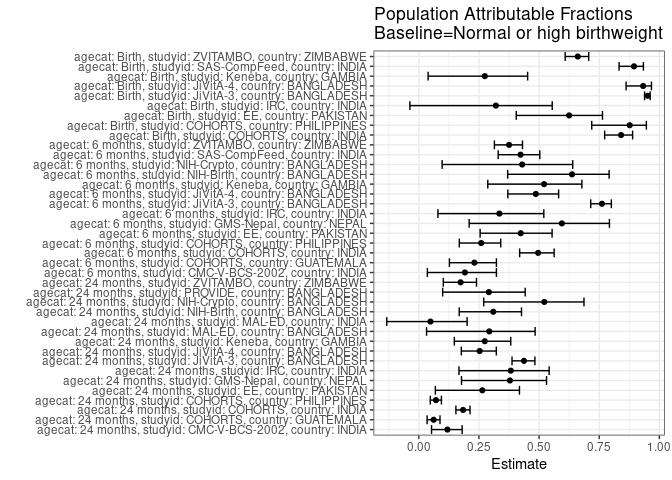

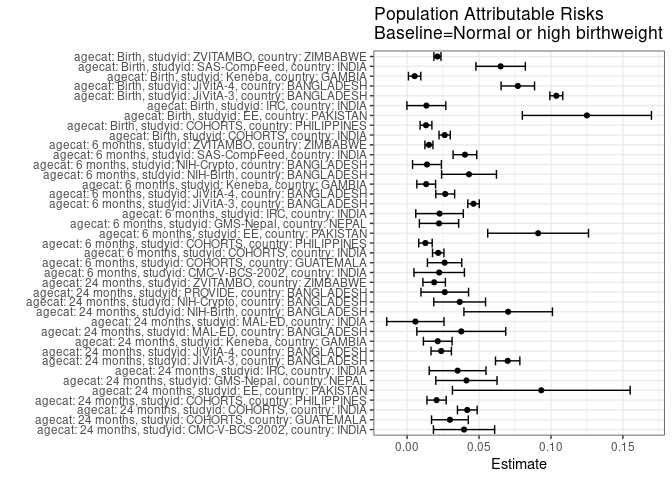

## Results Table

### Parameter: TSM

| agecat | studyid | country | intervention_level | baseline_level | estimate | ci_lower | ci_upper |
| --- | --- | --- | --- | --- | --- | --- | --- |
| Birth | COHORTS | INDIA | Normal or high birthweight | NA | 0.0049355 | 0.0030429 | 0.0068280 |
| Birth | COHORTS | INDIA | Low birthweight | NA | 0.1313869 | 0.1134969 | 0.1492768 |
| Birth | COHORTS | PHILIPPINES | Normal or high birthweight | NA | 0.0018457 | 0.0002291 | 0.0034623 |
| Birth | COHORTS | PHILIPPINES | Low birthweight | NA | 0.1355932 | 0.0965193 | 0.1746672 |
| Birth | EE | PAKISTAN | Normal or high birthweight | NA | 0.0750000 | 0.0341025 | 0.1158975 |
| Birth | EE | PAKISTAN | Low birthweight | NA | 0.4500000 | 0.3407561 | 0.5592439 |
| Birth | IRC | INDIA | Normal or high birthweight | NA | 0.0283912 | 0.0100839 | 0.0466984 |
| Birth | IRC | INDIA | Low birthweight | NA | 0.1060606 | 0.0316774 | 0.1804438 |
| Birth | JiVitA-3 | BANGLADESH | Normal or high birthweight | NA | 0.0052885 | 0.0040146 | 0.0065624 |
| Birth | JiVitA-3 | BANGLADESH | Low birthweight | NA | 0.2480200 | 0.2387225 | 0.2573175 |
| Birth | JiVitA-4 | BANGLADESH | Normal or high birthweight | NA | 0.0055586 | 0.0014892 | 0.0096281 |
| Birth | JiVitA-4 | BANGLADESH | Low birthweight | NA | 0.2177734 | 0.1885211 | 0.2470258 |
| Birth | Keneba | GAMBIA | Normal or high birthweight | NA | 0.0137615 | 0.0074459 | 0.0200770 |
| Birth | Keneba | GAMBIA | Low birthweight | NA | 0.0497738 | 0.0210919 | 0.0784556 |
| Birth | SAS-CompFeed | INDIA | Normal or high birthweight | NA | 0.0076586 | 0.0028611 | 0.0124562 |
| Birth | SAS-CompFeed | INDIA | Low birthweight | NA | 0.2485207 | 0.1798026 | 0.3172388 |
| Birth | ZVITAMBO | ZIMBABWE | Normal or high birthweight | NA | 0.0108140 | 0.0089579 | 0.0126700 |
| Birth | ZVITAMBO | ZIMBABWE | Low birthweight | NA | 0.1641241 | 0.1474735 | 0.1807747 |
| 6 months | CMC-V-BCS-2002 | INDIA | Normal or high birthweight | NA | 0.0940439 | 0.0619683 | 0.1261194 |
| 6 months | CMC-V-BCS-2002 | INDIA | Low birthweight | NA | 0.2857143 | 0.1489012 | 0.4225274 |
| 6 months | COHORTS | GUATEMALA | Normal or high birthweight | NA | 0.0867710 | 0.0659486 | 0.1075933 |
| 6 months | COHORTS | GUATEMALA | Low birthweight | NA | 0.3823529 | 0.2667742 | 0.4979317 |
| 6 months | COHORTS | INDIA | Normal or high birthweight | NA | 0.0219780 | 0.0179159 | 0.0260401 |
| 6 months | COHORTS | INDIA | Low birthweight | NA | 0.1297771 | 0.1111904 | 0.1483638 |
| 6 months | COHORTS | PHILIPPINES | Normal or high birthweight | NA | 0.0363937 | 0.0289281 | 0.0438593 |
| 6 months | COHORTS | PHILIPPINES | Low birthweight | NA | 0.1733871 | 0.1262608 | 0.2205134 |
| 6 months | EE | PAKISTAN | Normal or high birthweight | NA | 0.1239669 | 0.0823914 | 0.1655425 |
| 6 months | EE | PAKISTAN | Low birthweight | NA | 0.3846154 | 0.3008726 | 0.4683582 |
| 6 months | GMS-Nepal | NEPAL | Normal or high birthweight | NA | 0.0151134 | 0.0031014 | 0.0271253 |
| 6 months | GMS-Nepal | NEPAL | Low birthweight | NA | 0.0903614 | 0.0467092 | 0.1340136 |
| 6 months | IRC | INDIA | Normal or high birthweight | NA | 0.0447761 | 0.0226021 | 0.0669501 |
| 6 months | IRC | INDIA | Low birthweight | NA | 0.1818182 | 0.0886512 | 0.2749851 |
| 6 months | JiVitA-3 | BANGLADESH | Normal or high birthweight | NA | 0.0144754 | 0.0116151 | 0.0173357 |
| 6 months | JiVitA-3 | BANGLADESH | Low birthweight | NA | 0.1275342 | 0.1183642 | 0.1367043 |
| 6 months | JiVitA-4 | BANGLADESH | Normal or high birthweight | NA | 0.0279627 | 0.0203215 | 0.0356039 |
| 6 months | JiVitA-4 | BANGLADESH | Low birthweight | NA | 0.1311475 | 0.1075919 | 0.1547032 |
| 6 months | Keneba | GAMBIA | Normal or high birthweight | NA | 0.0122164 | 0.0058540 | 0.0185788 |
| 6 months | Keneba | GAMBIA | Low birthweight | NA | 0.1063830 | 0.0622926 | 0.1504734 |
| 6 months | NIH-Birth | BANGLADESH | Normal or high birthweight | NA | 0.0245232 | 0.0086840 | 0.0403623 |
| 6 months | NIH-Birth | BANGLADESH | Low birthweight | NA | 0.1721854 | 0.1119095 | 0.2324614 |
| 6 months | NIH-Crypto | BANGLADESH | Normal or high birthweight | NA | 0.0183486 | 0.0070732 | 0.0296241 |
| 6 months | NIH-Crypto | BANGLADESH | Low birthweight | NA | 0.0764706 | 0.0364945 | 0.1164467 |
| 6 months | SAS-CompFeed | INDIA | Normal or high birthweight | NA | 0.0548355 | 0.0386045 | 0.0710665 |
| 6 months | SAS-CompFeed | INDIA | Low birthweight | NA | 0.2198142 | 0.1864957 | 0.2531328 |
| 6 months | ZVITAMBO | ZIMBABWE | Normal or high birthweight | NA | 0.0252445 | 0.0217097 | 0.0287794 |
| 6 months | ZVITAMBO | ZIMBABWE | Low birthweight | NA | 0.1476636 | 0.1264055 | 0.1689216 |
| 24 months | CMC-V-BCS-2002 | INDIA | Normal or high birthweight | NA | 0.2937500 | 0.2437764 | 0.3437236 |
| 24 months | CMC-V-BCS-2002 | INDIA | Low birthweight | NA | 0.6279070 | 0.4832344 | 0.7725796 |
| 24 months | COHORTS | GUATEMALA | Normal or high birthweight | NA | 0.4533107 | 0.4130767 | 0.4935447 |
| 24 months | COHORTS | GUATEMALA | Low birthweight | NA | 0.7704918 | 0.6648829 | 0.8761007 |
| 24 months | COHORTS | INDIA | Normal or high birthweight | NA | 0.1856166 | 0.1734891 | 0.1977441 |
| 24 months | COHORTS | INDIA | Low birthweight | NA | 0.4092409 | 0.3772737 | 0.4412082 |
| 24 months | COHORTS | PHILIPPINES | Normal or high birthweight | NA | 0.2675479 | 0.2490206 | 0.2860751 |
| 24 months | COHORTS | PHILIPPINES | Low birthweight | NA | 0.5000000 | 0.4326806 | 0.5673194 |
| 24 months | EE | PAKISTAN | Normal or high birthweight | NA | 0.2600000 | 0.1737707 | 0.3462293 |
| 24 months | EE | PAKISTAN | Low birthweight | NA | 0.4925373 | 0.3724668 | 0.6126079 |
| 24 months | GMS-Nepal | NEPAL | Normal or high birthweight | NA | 0.0676056 | 0.0414617 | 0.0937496 |
| 24 months | GMS-Nepal | NEPAL | Low birthweight | NA | 0.2196970 | 0.1489918 | 0.2904021 |
| 24 months | IRC | INDIA | Normal or high birthweight | NA | 0.0567164 | 0.0319170 | 0.0815158 |
| 24 months | IRC | INDIA | Low birthweight | NA | 0.2647059 | 0.1597165 | 0.3696953 |
| 24 months | JiVitA-3 | BANGLADESH | Normal or high birthweight | NA | 0.0900731 | 0.0804445 | 0.0997017 |
| 24 months | JiVitA-3 | BANGLADESH | Low birthweight | NA | 0.2566862 | 0.2391133 | 0.2742592 |
| 24 months | JiVitA-4 | BANGLADESH | Normal or high birthweight | NA | 0.0700508 | 0.0593501 | 0.0807514 |
| 24 months | JiVitA-4 | BANGLADESH | Low birthweight | NA | 0.1601896 | 0.1356807 | 0.1846985 |
| 24 months | Keneba | GAMBIA | Normal or high birthweight | NA | 0.0563536 | 0.0413223 | 0.0713848 |
| 24 months | Keneba | GAMBIA | Low birthweight | NA | 0.2052980 | 0.1408425 | 0.2697535 |
| 24 months | MAL-ED | BANGLADESH | Normal or high birthweight | NA | 0.0909091 | 0.0469398 | 0.1348784 |
| 24 months | MAL-ED | BANGLADESH | Low birthweight | NA | 0.2666667 | 0.1371537 | 0.3961797 |
| 24 months | MAL-ED | INDIA | Normal or high birthweight | NA | 0.1135135 | 0.0676972 | 0.1593299 |
| 24 months | MAL-ED | INDIA | Low birthweight | NA | 0.1515152 | 0.0289013 | 0.2741290 |
| 24 months | NIH-Birth | BANGLADESH | Normal or high birthweight | NA | 0.1567944 | 0.1146768 | 0.1989121 |
| 24 months | NIH-Birth | BANGLADESH | Low birthweight | NA | 0.3858268 | 0.3010625 | 0.4705911 |
| 24 months | NIH-Crypto | BANGLADESH | Normal or high birthweight | NA | 0.0335052 | 0.0155822 | 0.0514282 |
| 24 months | NIH-Crypto | BANGLADESH | Low birthweight | NA | 0.1825397 | 0.1150251 | 0.2500543 |
| 24 months | PROVIDE | BANGLADESH | Normal or high birthweight | NA | 0.0637813 | 0.0409028 | 0.0866598 |
| 24 months | PROVIDE | BANGLADESH | Low birthweight | NA | 0.1726619 | 0.1097755 | 0.2355482 |
| 24 months | ZVITAMBO | ZIMBABWE | Normal or high birthweight | NA | 0.0894591 | 0.0747237 | 0.1041944 |
| 24 months | ZVITAMBO | ZIMBABWE | Low birthweight | NA | 0.2487047 | 0.1877019 | 0.3097074 |

### Parameter: E(Y)

| agecat | studyid | country | intervention_level | baseline_level | estimate | ci_lower | ci_upper |
| --- | --- | --- | --- | --- | --- | --- | --- |
| Birth | COHORTS | INDIA | NA | NA | 0.0310334 | 0.0268616 | 0.0352053 |
| Birth | COHORTS | PHILIPPINES | NA | NA | 0.0149800 | 0.0106354 | 0.0193246 |
| Birth | EE | PAKISTAN | NA | NA | 0.2000000 | 0.1492882 | 0.2507118 |
| Birth | IRC | INDIA | NA | NA | 0.0417755 | 0.0217118 | 0.0618391 |
| Birth | JiVitA-3 | BANGLADESH | NA | NA | 0.1090229 | 0.1044694 | 0.1135764 |
| Birth | JiVitA-4 | BANGLADESH | NA | NA | 0.0825363 | 0.0708486 | 0.0942240 |
| Birth | Keneba | GAMBIA | NA | NA | 0.0189666 | 0.0121272 | 0.0258061 |
| Birth | SAS-CompFeed | INDIA | NA | NA | 0.0726837 | 0.0523147 | 0.0930527 |
| Birth | ZVITAMBO | ZIMBABWE | NA | NA | 0.0318872 | 0.0289588 | 0.0348156 |
| 6 months | CMC-V-BCS-2002 | INDIA | NA | NA | 0.1163435 | 0.0832220 | 0.1494650 |
| 6 months | COHORTS | GUATEMALA | NA | NA | 0.1128405 | 0.0904926 | 0.1351883 |
| 6 months | COHORTS | INDIA | NA | NA | 0.0436033 | 0.0385446 | 0.0486620 |
| 6 months | COHORTS | PHILIPPINES | NA | NA | 0.0491373 | 0.0409307 | 0.0573439 |
| 6 months | EE | PAKISTAN | NA | NA | 0.2150538 | 0.1732462 | 0.2568613 |
| 6 months | GMS-Nepal | NEPAL | NA | NA | 0.0373002 | 0.0216334 | 0.0529670 |
| 6 months | IRC | INDIA | NA | NA | 0.0673317 | 0.0427738 | 0.0918896 |
| 6 months | JiVitA-3 | BANGLADESH | NA | NA | 0.0606511 | 0.0563622 | 0.0649400 |
| 6 months | JiVitA-4 | BANGLADESH | NA | NA | 0.0544420 | 0.0459722 | 0.0629117 |
| 6 months | Keneba | GAMBIA | NA | NA | 0.0254873 | 0.0170269 | 0.0339476 |
| 6 months | NIH-Birth | BANGLADESH | NA | NA | 0.0675676 | 0.0459314 | 0.0892038 |
| 6 months | NIH-Crypto | BANGLADESH | NA | NA | 0.0321678 | 0.0192256 | 0.0451101 |
| 6 months | SAS-CompFeed | INDIA | NA | NA | 0.0950226 | 0.0765320 | 0.1135132 |
| 6 months | ZVITAMBO | ZIMBABWE | NA | NA | 0.0404122 | 0.0362587 | 0.0445657 |
| 24 months | CMC-V-BCS-2002 | INDIA | NA | NA | 0.3333333 | 0.2847723 | 0.3818943 |
| 24 months | COHORTS | GUATEMALA | NA | NA | 0.4830769 | 0.4446313 | 0.5215225 |
| 24 months | COHORTS | INDIA | NA | NA | 0.2274599 | 0.2156709 | 0.2392489 |
| 24 months | COHORTS | PHILIPPINES | NA | NA | 0.2880299 | 0.2699315 | 0.3061283 |
| 24 months | EE | PAKISTAN | NA | NA | 0.3532934 | 0.2805798 | 0.4260070 |
| 24 months | GMS-Nepal | NEPAL | NA | NA | 0.1088296 | 0.0811421 | 0.1365171 |
| 24 months | IRC | INDIA | NA | NA | 0.0918114 | 0.0635840 | 0.1200388 |
| 24 months | JiVitA-3 | BANGLADESH | NA | NA | 0.1599836 | 0.1502803 | 0.1696868 |
| 24 months | JiVitA-4 | BANGLADESH | NA | NA | 0.0937656 | 0.0834379 | 0.1040932 |
| 24 months | Keneba | GAMBIA | NA | NA | 0.0776515 | 0.0615026 | 0.0938005 |
| 24 months | MAL-ED | BANGLADESH | NA | NA | 0.1285714 | 0.0831916 | 0.1739513 |
| 24 months | MAL-ED | INDIA | NA | NA | 0.1192661 | 0.0761440 | 0.1623881 |
| 24 months | NIH-Birth | BANGLADESH | NA | NA | 0.2270531 | 0.1866503 | 0.2674560 |
| 24 months | NIH-Crypto | BANGLADESH | NA | NA | 0.0700389 | 0.0479542 | 0.0921236 |
| 24 months | PROVIDE | BANGLADESH | NA | NA | 0.0899654 | 0.0666186 | 0.1133122 |
| 24 months | ZVITAMBO | ZIMBABWE | NA | NA | 0.1082569 | 0.0931919 | 0.1233219 |

### Parameter: RR

| agecat | studyid | country | intervention_level | baseline_level | estimate | ci_lower | ci_upper |
| --- | --- | --- | --- | --- | --- | --- | --- |
| Birth | COHORTS | INDIA | Normal or high birthweight | Normal or high birthweight | 1.000000 | 1.0000000 | 1.000000 |
| Birth | COHORTS | INDIA | Low birthweight | Normal or high birthweight | 26.620999 | 17.7215809 | 39.989525 |
| Birth | COHORTS | PHILIPPINES | Normal or high birthweight | Normal or high birthweight | 1.000000 | 1.0000000 | 1.000000 |
| Birth | COHORTS | PHILIPPINES | Low birthweight | Normal or high birthweight | 73.464407 | 29.2170860 | 184.721332 |
| Birth | EE | PAKISTAN | Normal or high birthweight | Normal or high birthweight | 1.000000 | 1.0000000 | 1.000000 |
| Birth | EE | PAKISTAN | Low birthweight | Normal or high birthweight | 6.000000 | 3.3031037 | 10.898840 |
| Birth | IRC | INDIA | Normal or high birthweight | Normal or high birthweight | 1.000000 | 1.0000000 | 1.000000 |
| Birth | IRC | INDIA | Low birthweight | Normal or high birthweight | 3.735690 | 1.4408347 | 9.685623 |
| Birth | JiVitA-3 | BANGLADESH | Normal or high birthweight | Normal or high birthweight | 1.000000 | 1.0000000 | 1.000000 |
| Birth | JiVitA-3 | BANGLADESH | Low birthweight | Normal or high birthweight | 46.897666 | 36.8223851 | 59.729728 |
| Birth | JiVitA-4 | BANGLADESH | Normal or high birthweight | Normal or high birthweight | 1.000000 | 1.0000000 | 1.000000 |
| Birth | JiVitA-4 | BANGLADESH | Low birthweight | Normal or high birthweight | 39.177441 | 18.5185250 | 82.883054 |
| Birth | Keneba | GAMBIA | Normal or high birthweight | Normal or high birthweight | 1.000000 | 1.0000000 | 1.000000 |
| Birth | Keneba | GAMBIA | Low birthweight | Normal or high birthweight | 3.616893 | 1.7314365 | 7.555527 |
| Birth | SAS-CompFeed | INDIA | Normal or high birthweight | Normal or high birthweight | 1.000000 | 1.0000000 | 1.000000 |
| Birth | SAS-CompFeed | INDIA | Low birthweight | Normal or high birthweight | 32.449704 | 19.4675936 | 54.089032 |
| Birth | ZVITAMBO | ZIMBABWE | Normal or high birthweight | Normal or high birthweight | 1.000000 | 1.0000000 | 1.000000 |
| Birth | ZVITAMBO | ZIMBABWE | Low birthweight | Normal or high birthweight | 15.177030 | 12.4336447 | 18.525723 |
| 6 months | CMC-V-BCS-2002 | INDIA | Normal or high birthweight | Normal or high birthweight | 1.000000 | 1.0000000 | 1.000000 |
| 6 months | CMC-V-BCS-2002 | INDIA | Low birthweight | Normal or high birthweight | 3.038095 | 1.6876456 | 5.469171 |
| 6 months | COHORTS | GUATEMALA | Normal or high birthweight | Normal or high birthweight | 1.000000 | 1.0000000 | 1.000000 |
| 6 months | COHORTS | GUATEMALA | Low birthweight | Normal or high birthweight | 4.406461 | 2.9955222 | 6.481974 |
| 6 months | COHORTS | INDIA | Normal or high birthweight | Normal or high birthweight | 1.000000 | 1.0000000 | 1.000000 |
| 6 months | COHORTS | INDIA | Low birthweight | Normal or high birthweight | 5.904857 | 4.6737142 | 7.460305 |
| 6 months | COHORTS | PHILIPPINES | Normal or high birthweight | Normal or high birthweight | 1.000000 | 1.0000000 | 1.000000 |
| 6 months | COHORTS | PHILIPPINES | Low birthweight | Normal or high birthweight | 4.764204 | 3.3892547 | 6.696943 |
| 6 months | EE | PAKISTAN | Normal or high birthweight | Normal or high birthweight | 1.000000 | 1.0000000 | 1.000000 |
| 6 months | EE | PAKISTAN | Low birthweight | Normal or high birthweight | 3.102564 | 2.0800122 | 4.627811 |
| 6 months | GMS-Nepal | NEPAL | Normal or high birthweight | Normal or high birthweight | 1.000000 | 1.0000000 | 1.000000 |
| 6 months | GMS-Nepal | NEPAL | Low birthweight | Normal or high birthweight | 5.978916 | 2.3588012 | 15.154915 |
| 6 months | IRC | INDIA | Normal or high birthweight | Normal or high birthweight | 1.000000 | 1.0000000 | 1.000000 |
| 6 months | IRC | INDIA | Low birthweight | Normal or high birthweight | 4.060606 | 1.9911680 | 8.280829 |
| 6 months | JiVitA-3 | BANGLADESH | Normal or high birthweight | Normal or high birthweight | 1.000000 | 1.0000000 | 1.000000 |
| 6 months | JiVitA-3 | BANGLADESH | Low birthweight | Normal or high birthweight | 8.810401 | 7.1542140 | 10.849993 |
| 6 months | JiVitA-4 | BANGLADESH | Normal or high birthweight | Normal or high birthweight | 1.000000 | 1.0000000 | 1.000000 |
| 6 months | JiVitA-4 | BANGLADESH | Low birthweight | Normal or high birthweight | 4.690086 | 3.3846631 | 6.498994 |
| 6 months | Keneba | GAMBIA | Normal or high birthweight | Normal or high birthweight | 1.000000 | 1.0000000 | 1.000000 |
| 6 months | Keneba | GAMBIA | Low birthweight | Normal or high birthweight | 8.708207 | 4.4757602 | 16.943013 |
| 6 months | NIH-Birth | BANGLADESH | Normal or high birthweight | Normal or high birthweight | 1.000000 | 1.0000000 | 1.000000 |
| 6 months | NIH-Birth | BANGLADESH | Low birthweight | Normal or high birthweight | 7.021339 | 3.3679464 | 14.637764 |
| 6 months | NIH-Crypto | BANGLADESH | Normal or high birthweight | Normal or high birthweight | 1.000000 | 1.0000000 | 1.000000 |
| 6 months | NIH-Crypto | BANGLADESH | Low birthweight | Normal or high birthweight | 4.167647 | 1.8599751 | 9.338449 |
| 6 months | SAS-CompFeed | INDIA | Normal or high birthweight | Normal or high birthweight | 1.000000 | 1.0000000 | 1.000000 |
| 6 months | SAS-CompFeed | INDIA | Low birthweight | Normal or high birthweight | 4.008612 | 2.9791380 | 5.393833 |
| 6 months | ZVITAMBO | ZIMBABWE | Normal or high birthweight | Normal or high birthweight | 1.000000 | 1.0000000 | 1.000000 |
| 6 months | ZVITAMBO | ZIMBABWE | Low birthweight | Normal or high birthweight | 5.849332 | 4.7850609 | 7.150314 |
| 24 months | CMC-V-BCS-2002 | INDIA | Normal or high birthweight | Normal or high birthweight | 1.000000 | 1.0000000 | 1.000000 |
| 24 months | CMC-V-BCS-2002 | INDIA | Low birthweight | Normal or high birthweight | 2.137556 | 1.6052149 | 2.846438 |
| 24 months | COHORTS | GUATEMALA | Normal or high birthweight | Normal or high birthweight | 1.000000 | 1.0000000 | 1.000000 |
| 24 months | COHORTS | GUATEMALA | Low birthweight | Normal or high birthweight | 1.699699 | 1.4436249 | 2.001197 |
| 24 months | COHORTS | INDIA | Normal or high birthweight | Normal or high birthweight | 1.000000 | 1.0000000 | 1.000000 |
| 24 months | COHORTS | INDIA | Low birthweight | Normal or high birthweight | 2.204765 | 1.9912940 | 2.441120 |
| 24 months | COHORTS | PHILIPPINES | Normal or high birthweight | Normal or high birthweight | 1.000000 | 1.0000000 | 1.000000 |
| 24 months | COHORTS | PHILIPPINES | Low birthweight | Normal or high birthweight | 1.868825 | 1.6062566 | 2.174313 |
| 24 months | EE | PAKISTAN | Normal or high birthweight | Normal or high birthweight | 1.000000 | 1.0000000 | 1.000000 |
| 24 months | EE | PAKISTAN | Low birthweight | Normal or high birthweight | 1.894374 | 1.2551823 | 2.859070 |
| 24 months | GMS-Nepal | NEPAL | Normal or high birthweight | Normal or high birthweight | 1.000000 | 1.0000000 | 1.000000 |
| 24 months | GMS-Nepal | NEPAL | Low birthweight | Normal or high birthweight | 3.249684 | 1.9649089 | 5.374523 |
| 24 months | IRC | INDIA | Normal or high birthweight | Normal or high birthweight | 1.000000 | 1.0000000 | 1.000000 |
| 24 months | IRC | INDIA | Low birthweight | Normal or high birthweight | 4.667183 | 2.5862655 | 8.422412 |
| 24 months | JiVitA-3 | BANGLADESH | Normal or high birthweight | Normal or high birthweight | 1.000000 | 1.0000000 | 1.000000 |
| 24 months | JiVitA-3 | BANGLADESH | Low birthweight | Normal or high birthweight | 2.849755 | 2.5137521 | 3.230670 |
| 24 months | JiVitA-4 | BANGLADESH | Normal or high birthweight | Normal or high birthweight | 1.000000 | 1.0000000 | 1.000000 |
| 24 months | JiVitA-4 | BANGLADESH | Low birthweight | Normal or high birthweight | 2.286764 | 1.8425816 | 2.838024 |
| 24 months | Keneba | GAMBIA | Normal or high birthweight | Normal or high birthweight | 1.000000 | 1.0000000 | 1.000000 |
| 24 months | Keneba | GAMBIA | Low birthweight | Normal or high birthweight | 3.643033 | 2.4129496 | 5.500195 |
| 24 months | MAL-ED | BANGLADESH | Normal or high birthweight | Normal or high birthweight | 1.000000 | 1.0000000 | 1.000000 |
| 24 months | MAL-ED | BANGLADESH | Low birthweight | Normal or high birthweight | 2.933333 | 1.4780350 | 5.821543 |
| 24 months | MAL-ED | INDIA | Normal or high birthweight | Normal or high birthweight | 1.000000 | 1.0000000 | 1.000000 |
| 24 months | MAL-ED | INDIA | Low birthweight | Normal or high birthweight | 1.334776 | 0.5403395 | 3.297238 |
| 24 months | NIH-Birth | BANGLADESH | Normal or high birthweight | Normal or high birthweight | 1.000000 | 1.0000000 | 1.000000 |
| 24 months | NIH-Birth | BANGLADESH | Low birthweight | Normal or high birthweight | 2.460717 | 1.7392177 | 3.481525 |
| 24 months | NIH-Crypto | BANGLADESH | Normal or high birthweight | Normal or high birthweight | 1.000000 | 1.0000000 | 1.000000 |
| 24 months | NIH-Crypto | BANGLADESH | Low birthweight | Normal or high birthweight | 5.448107 | 2.8431748 | 10.439694 |
| 24 months | PROVIDE | BANGLADESH | Normal or high birthweight | Normal or high birthweight | 1.000000 | 1.0000000 | 1.000000 |
| 24 months | PROVIDE | BANGLADESH | Low birthweight | Normal or high birthweight | 2.707092 | 1.6236540 | 4.513489 |
| 24 months | ZVITAMBO | ZIMBABWE | Normal or high birthweight | Normal or high birthweight | 1.000000 | 1.0000000 | 1.000000 |
| 24 months | ZVITAMBO | ZIMBABWE | Low birthweight | Normal or high birthweight | 2.780094 | 2.0689228 | 3.735723 |

### Parameter: PAR

| agecat | studyid | country | intervention_level | baseline_level | estimate | ci_lower | ci_upper |
| --- | --- | --- | --- | --- | --- | --- | --- |
| Birth | COHORTS | INDIA | Normal or high birthweight | NA | 0.0260980 | 0.0221863 | 0.0300097 |
| Birth | COHORTS | PHILIPPINES | Normal or high birthweight | NA | 0.0131343 | 0.0090385 | 0.0172301 |
| Birth | EE | PAKISTAN | Normal or high birthweight | NA | 0.1250000 | 0.0801207 | 0.1698793 |
| Birth | IRC | INDIA | Normal or high birthweight | NA | 0.0133843 | -0.0001400 | 0.0269086 |
| Birth | JiVitA-3 | BANGLADESH | Normal or high birthweight | NA | 0.1037344 | 0.0992413 | 0.1082274 |
| Birth | JiVitA-4 | BANGLADESH | Normal or high birthweight | NA | 0.0769777 | 0.0653481 | 0.0886072 |
| Birth | Keneba | GAMBIA | Normal or high birthweight | NA | 0.0052052 | 0.0009130 | 0.0094974 |
| Birth | SAS-CompFeed | INDIA | Normal or high birthweight | NA | 0.0650251 | 0.0478410 | 0.0822091 |
| Birth | ZVITAMBO | ZIMBABWE | Normal or high birthweight | NA | 0.0210732 | 0.0186080 | 0.0235384 |
| 6 months | CMC-V-BCS-2002 | INDIA | Normal or high birthweight | NA | 0.0222996 | 0.0047614 | 0.0398378 |
| 6 months | COHORTS | GUATEMALA | Normal or high birthweight | NA | 0.0260695 | 0.0141390 | 0.0380000 |
| 6 months | COHORTS | INDIA | Normal or high birthweight | NA | 0.0216252 | 0.0176616 | 0.0255888 |
| 6 months | COHORTS | PHILIPPINES | Normal or high birthweight | NA | 0.0127436 | 0.0080550 | 0.0174321 |
| 6 months | EE | PAKISTAN | Normal or high birthweight | NA | 0.0910868 | 0.0560518 | 0.1261219 |
| 6 months | GMS-Nepal | NEPAL | Normal or high birthweight | NA | 0.0221868 | 0.0085395 | 0.0358341 |
| 6 months | IRC | INDIA | Normal or high birthweight | NA | 0.0225556 | 0.0060251 | 0.0390860 |
| 6 months | JiVitA-3 | BANGLADESH | Normal or high birthweight | NA | 0.0461757 | 0.0421790 | 0.0501723 |
| 6 months | JiVitA-4 | BANGLADESH | Normal or high birthweight | NA | 0.0264793 | 0.0199199 | 0.0330386 |
| 6 months | Keneba | GAMBIA | Normal or high birthweight | NA | 0.0132709 | 0.0067511 | 0.0197906 |
| 6 months | NIH-Birth | BANGLADESH | Normal or high birthweight | NA | 0.0430444 | 0.0239784 | 0.0621104 |
| 6 months | NIH-Crypto | BANGLADESH | Normal or high birthweight | NA | 0.0138192 | 0.0037782 | 0.0238602 |
| 6 months | SAS-CompFeed | INDIA | Normal or high birthweight | NA | 0.0401871 | 0.0319661 | 0.0484082 |
| 6 months | ZVITAMBO | ZIMBABWE | Normal or high birthweight | NA | 0.0151677 | 0.0123654 | 0.0179700 |
| 24 months | CMC-V-BCS-2002 | INDIA | Normal or high birthweight | NA | 0.0395833 | 0.0183119 | 0.0608548 |
| 24 months | COHORTS | GUATEMALA | Normal or high birthweight | NA | 0.0297662 | 0.0169943 | 0.0425382 |
| 24 months | COHORTS | INDIA | Normal or high birthweight | NA | 0.0418432 | 0.0349917 | 0.0486948 |
| 24 months | COHORTS | PHILIPPINES | Normal or high birthweight | NA | 0.0204821 | 0.0137899 | 0.0271742 |
| 24 months | EE | PAKISTAN | Normal or high birthweight | NA | 0.0932934 | 0.0315037 | 0.1550832 |
| 24 months | GMS-Nepal | NEPAL | Normal or high birthweight | NA | 0.0412239 | 0.0199257 | 0.0625222 |
| 24 months | IRC | INDIA | Normal or high birthweight | NA | 0.0350950 | 0.0153637 | 0.0548263 |
| 24 months | JiVitA-3 | BANGLADESH | Normal or high birthweight | NA | 0.0699105 | 0.0614416 | 0.0783794 |
| 24 months | JiVitA-4 | BANGLADESH | Normal or high birthweight | NA | 0.0237148 | 0.0166249 | 0.0308048 |
| 24 months | Keneba | GAMBIA | Normal or high birthweight | NA | 0.0212979 | 0.0113247 | 0.0312712 |
| 24 months | MAL-ED | BANGLADESH | Normal or high birthweight | NA | 0.0376623 | 0.0067660 | 0.0685587 |
| 24 months | MAL-ED | INDIA | Normal or high birthweight | NA | 0.0057525 | -0.0141444 | 0.0256495 |
| 24 months | NIH-Birth | BANGLADESH | Normal or high birthweight | NA | 0.0702587 | 0.0394882 | 0.1010292 |
| 24 months | NIH-Crypto | BANGLADESH | Normal or high birthweight | NA | 0.0365338 | 0.0185340 | 0.0545335 |
| 24 months | PROVIDE | BANGLADESH | Normal or high birthweight | NA | 0.0261841 | 0.0096493 | 0.0427188 |
| 24 months | ZVITAMBO | ZIMBABWE | Normal or high birthweight | NA | 0.0187978 | 0.0109821 | 0.0266135 |

### Parameter: PAF

| agecat | studyid | country | intervention_level | baseline_level | estimate | ci_lower | ci_upper |
| --- | --- | --- | --- | --- | --- | --- | --- |
| Birth | COHORTS | INDIA | Normal or high birthweight | NA | 0.8409632 | 0.7725567 | 0.8887956 |
| Birth | COHORTS | PHILIPPINES | Normal or high birthweight | NA | 0.8767893 | 0.7188230 | 0.9460095 |
| Birth | EE | PAKISTAN | Normal or high birthweight | NA | 0.6250000 | 0.4050898 | 0.7636198 |
| Birth | IRC | INDIA | Normal or high birthweight | NA | 0.3203864 | -0.0371590 | 0.5546733 |
| Birth | JiVitA-3 | BANGLADESH | Normal or high birthweight | NA | 0.9514915 | 0.9385397 | 0.9617139 |
| Birth | JiVitA-4 | BANGLADESH | Normal or high birthweight | NA | 0.9326521 | 0.8617762 | 0.9671856 |
| Birth | Keneba | GAMBIA | Normal or high birthweight | NA | 0.2744385 | 0.0386214 | 0.4524119 |
| Birth | SAS-CompFeed | INDIA | Normal or high birthweight | NA | 0.8946305 | 0.8325207 | 0.9337069 |
| Birth | ZVITAMBO | ZIMBABWE | Normal or high birthweight | NA | 0.6608676 | 0.6084475 | 0.7062699 |
| 6 months | CMC-V-BCS-2002 | INDIA | Normal or high birthweight | NA | 0.1916704 | 0.0355277 | 0.3225344 |
| 6 months | COHORTS | GUATEMALA | Normal or high birthweight | NA | 0.2310296 | 0.1271465 | 0.3225489 |
| 6 months | COHORTS | INDIA | Normal or high birthweight | NA | 0.4959546 | 0.4191970 | 0.5625681 |
| 6 months | COHORTS | PHILIPPINES | Normal or high birthweight | NA | 0.2593463 | 0.1683110 | 0.3404170 |
| 6 months | EE | PAKISTAN | Normal or high birthweight | NA | 0.4235537 | 0.2548268 | 0.5540764 |
| 6 months | GMS-Nepal | NEPAL | Normal or high birthweight | NA | 0.5948183 | 0.2092188 | 0.7923924 |
| 6 months | IRC | INDIA | Normal or high birthweight | NA | 0.3349917 | 0.0793898 | 0.5196273 |
| 6 months | JiVitA-3 | BANGLADESH | Normal or high birthweight | NA | 0.7613330 | 0.7146070 | 0.8004087 |
| 6 months | JiVitA-4 | BANGLADESH | Normal or high birthweight | NA | 0.4863757 | 0.3700720 | 0.5812063 |
| 6 months | Keneba | GAMBIA | Normal or high birthweight | NA | 0.5206858 | 0.2866905 | 0.6779208 |
| 6 months | NIH-Birth | BANGLADESH | Normal or high birthweight | NA | 0.6370572 | 0.3694075 | 0.7911052 |
| 6 months | NIH-Crypto | BANGLADESH | Normal or high birthweight | NA | 0.4295971 | 0.0969022 | 0.6397296 |
| 6 months | SAS-CompFeed | INDIA | Normal or high birthweight | NA | 0.4229217 | 0.3300385 | 0.5029276 |
| 6 months | ZVITAMBO | ZIMBABWE | Normal or high birthweight | NA | 0.3753248 | 0.3142203 | 0.4309849 |
| 24 months | CMC-V-BCS-2002 | INDIA | Normal or high birthweight | NA | 0.1187500 | 0.0528684 | 0.1800489 |
| 24 months | COHORTS | GUATEMALA | Normal or high birthweight | NA | 0.0616180 | 0.0344527 | 0.0880189 |
| 24 months | COHORTS | INDIA | Normal or high birthweight | NA | 0.1839588 | 0.1540977 | 0.2127659 |
| 24 months | COHORTS | PHILIPPINES | Normal or high birthweight | NA | 0.0711109 | 0.0476933 | 0.0939526 |
| 24 months | EE | PAKISTAN | Normal or high birthweight | NA | 0.2640678 | 0.0687461 | 0.4184226 |
| 24 months | GMS-Nepal | NEPAL | Normal or high birthweight | NA | 0.3787935 | 0.1774276 | 0.5308650 |
| 24 months | IRC | INDIA | Normal or high birthweight | NA | 0.3822509 | 0.1670189 | 0.5418697 |
| 24 months | JiVitA-3 | BANGLADESH | Normal or high birthweight | NA | 0.4369854 | 0.3874325 | 0.4825297 |
| 24 months | JiVitA-4 | BANGLADESH | Normal or high birthweight | NA | 0.2529161 | 0.1766544 | 0.3221141 |
| 24 months | Keneba | GAMBIA | Normal or high birthweight | NA | 0.2742757 | 0.1475642 | 0.3821520 |
| 24 months | MAL-ED | BANGLADESH | Normal or high birthweight | NA | 0.2929293 | 0.0321157 | 0.4834620 |
| 24 months | MAL-ED | INDIA | Normal or high birthweight | NA | 0.0482328 | -0.1333022 | 0.2006891 |
| 24 months | NIH-Birth | BANGLADESH | Normal or high birthweight | NA | 0.3094373 | 0.1679613 | 0.4268574 |
| 24 months | NIH-Crypto | BANGLADESH | Normal or high birthweight | NA | 0.5216208 | 0.2697509 | 0.6866184 |
| 24 months | PROVIDE | BANGLADESH | Normal or high birthweight | NA | 0.2910461 | 0.0990301 | 0.4421393 |
| 24 months | ZVITAMBO | ZIMBABWE | Normal or high birthweight | NA | 0.1736407 | 0.1017998 | 0.2397355 |